# Super 16 Word Cloud

## Bonus Task - WordCloud Library

#### 2/18/2023

In this notebook, we will use the wordcloud library to analyze a regular article put out by the NHL, the Super 16. In these weekly articles, several analysts give a list of the teams they believe to be the best 16 teams, ranked with the best team at #1, the second best team at #2, etc. These lists are compiled to make a Super 16 list. The article gives brief reasonings for each teams' ranking. The wordcloud library will be used to analyze the text in one of these articles so see if any trends emerge. For this notebook, we are looking at the text from https://www.nhl.com/news/super-16-nhl-power-rankings-decemeber-29/c-339259072. The main article text is in this repo's NHL_Article.txt file.

To start, we'll need to import the appropriate libraries.

```python
import matplotlib
import wordcloud
```

wordcloud depends on matplotlib, so we have to import both libraries.

With the libraries imported, we're ready to read our text file.

```python
text = open(r'NHL_Article.txt', mode='r').read()
```

With the text loaded, we're ready to create the wordcloud.

```python
stopwords = wordcloud.STOPWORDS

cloud = wordcloud.WordCloud(
    stopwords=stopwords,
    height = 600,
    width = 400
)
```

We've created an empty word cloud object with a few parameters set for it. The stopwords prevents certain words from being considered when analyzing text. This prevents common words like "the" and "a" from being included in the cloud. The wordcloud object has a height of 600 pixels and a width of 400 pixels.

Using the generate() method, we can create our actual wordcloud.

```python
cloud.generate(text)
```

```
<wordcloud.wordcloud.WordCloud at 0x272f219b8b0>
```

Wordcloud's to_image() method can be used to display the image

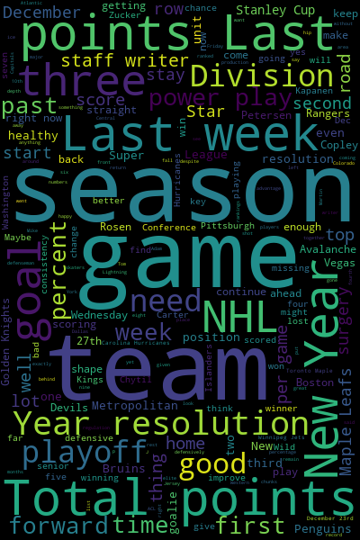

```python
cloud.to_image()
```

Many words appear that you might expect. Hockey is a team sport so it is no surprise that words like "team", "game", and "season" emerge as the largest words.

In a hockey game, if a player has a penalty, the opposing team goes on a "power play" where they are able to skate their full team, but the penalized player's team is on the "penalty kill" where they have to play with one fewer player on the ice. In the word cloud, "power play" has a fairly large result, but I was unable to find "penalty kill". This implies that analysts place a greater importance on a team's power play capabilities than their success on the penalty kill.

The word "surgery" has a fairly large result. You could infer that several of these teams are being impacted by a player's necessary surgery.

Several specific player names are mentioned. I was able to spot Petersen, Saad, Carter, Zucker, and Copley. You could infer that these player have appeared in the Wordcloud because they were mentioned several times in the article. This does not explain the nature of these players' impact on their team (positive or negative), but I think one could infer that they *are* impactful.

"Forward" is a class of position in hockey. Each team generally players with three offensively minded players, their forwards, and two defensive players, their defensemen. More specifically, forwards include a right wing, a center, and a left wing. The word "forward" has a sizeable result in the wordcloud, but "defensemen" is absent. It is difficult to know if this is a red herring, however, as "forward" could also just refer to the future, as in "going forward", "moving forward", "looking forward", etc. The wordcloud does not provide context, so one would need to read the article to know the actual context of the word "forward".

This wordcloud is an interesting way to analyze text files. You can see how frequently a given word is used in text, but you are unable to see the context in which it was used. STOPWORDS can be used to omit words you are uninterested in consideringI think that this is a wonderful tool to gain surface level information, even if it is somewhat unreliable as it lacks context. In my opinion, serious conclusions should not be drawn from a worldcloud alone. That said, I see nothing wrong from using a wordcloud as a starting point, *before* you actually read an article. This could allow you to glimpse into the future of what you will read and get certain concepts on your radar for your reading. The wordcloud could also supplement notetaking. Beyond its usefulness in data analysis, the wordcloud can be heavily customized for artistic expression. You can fit the wordcloud within specific shapes and using specific colors.